# Multivariate analysis of Gaussian data (MANOVA)

Part I

| Wagner H. Bonat | Walmes M. Zeviani |
| --- | --- |
| `wbonat@ufpr.br` | `walmes@ufpr.br` |
| LEG/DEST/UFPR | LEG/DEST/UFPR |

62<sup>a</sup> RBras & 17<sup>o</sup> SEAGRO  
July 24–28, 2017  
UFLA, Lavras/MG

# The univariate analysis of experimental data

# Response variables in designed experiments

- Designed experiments usually record several response variables.
  - Size variables (weight, height, width, diameter, volume, etc).
  - Production variables (fresh/dry matter, yield, etc).
  - Resistance variables (to disease, to stress, etc).
  - Chemical variables (P, K, pH, Ca, Mg, etc).
  - Mechanical variables (firmness, colors, etc).
  - Sensory variables (sweetness, astringency, acidicity, etc).
  - Performance variables (scores in math, language, running, swimming, etc).
  - Aesthetic variables (colors, shapes, harmony, complexity, etc)
- Sets of correlated variables for the same dimension (production, quality, leaning, flavor, etc).

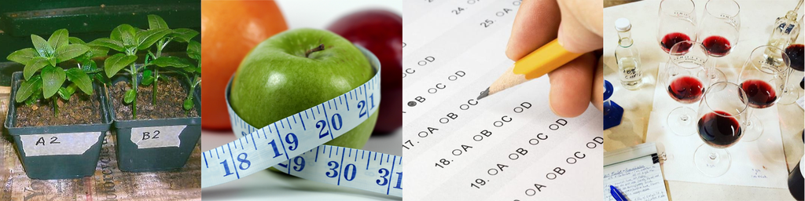

# Analysing the responses individually

Often, two situations occurs

1. The results are pratically the same for all responses.

   ```
   Table of means followed by letters from a pairwise multiple comparisons test to a 3-level factor in a RBD.

      Wtr   yield       tg    w100   Kconc
   1 37.5 23.93 a 163.40 a 14.86 a 17.72 a
   2   50 28.69 b 209.40 b 13.80 a 19.01 a
   3 62.5 29.83 b 215.60 b 13.83 a 18.32 a
   ```

   ```
   ANOVA tables for 4 responses in a RBD.

    Response yield :
               Df  Sum Sq Mean Sq F value  Pr(>F)
   blk          4  4.7999  1.2000  0.3937 0.80798
   Wtr          2 19.2544  9.6272  3.1585 0.09749
   Residuals    8 24.3842  3.0480

    Response tg :
               Df Sum Sq Mean Sq F value  Pr(>F)
   blk          4  456.4  114.10  0.7591 0.57990
   Wtr          2 1462.9  731.47  4.8667 0.04142
   Residuals    8 1202.4  150.30

    Response w100 :
               Df Sum Sq Mean Sq F value Pr(>F)
   blk          4 2.6981 0.67452  1.3088 0.3447
   Wtr          2 0.2942 0.14709  0.2854 0.7591
   Residuals    8 4.1230 0.51538

    Response Kconc :
               Df  Sum Sq Mean Sq F value  Pr(>F)
   blk          4  2.5354  0.6339  0.2837 0.88053
   Wtr          2 14.5229  7.2615  3.2506 0.09263
   Residuals    8 17.8711  2.2339
   ```

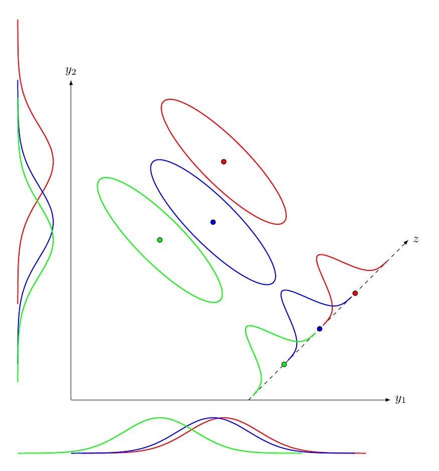

# Some questions

Its is difficult to know

- Which is the best (set of) variable to measure?
- Do the factors influence the response variables in the same way?

Probably, someone asked himself

- Which variables are more influenced by the factors?
- Which variables best indicate the effect of each factor?
- Can a new variable be expressed in terms of the measured ones?
- How this new variable summarizes all the results?

# Benefits and cautions

- If the response variables are correlated, we should explore this source of information.
- Multivariate models are more powerful to detect the effect of factors if the response variables are correlated.
- A more useful or compact description of the results can be obtained.
- Encourages a more global conclusion.
- New insights and formulations can be done for future research.
- BUT:
  - Its not obvious how to perform a multivariate analysis.
  - Its not obvious how to interpret their results.
  - There are less statistical methods available.
  - Most of them rely on the multivariate Gaussian distribution.

# Datasets

### `soybean`: water and potassium in the plant production

- Soybean (*Glicine max* L.) in greenhouse on a randomized block design.
- 3 water content levels (irrigation) $\times$ 5 potassium levels (fertilization).
- Responses: grain yield, weight of a hundred grains, number of grains, K concentration in the grain, number of (in)viable pods.

### `cotton`: impact of defoliation and growth stage

- Study the effect of defoliation levels at different growth stages of cotton in plant production.
- Made in greenhouse in a complete randomized design.
- Experimental unit: a plot with 2 cotton plants.
- 5 growth stages $\times$ 5 defoliation levels.
- Responses: number of bolls produced, total boll weight, plant height and number of plant nodes.

### `wrc`: soil management in the water retention curve

- Field experiment in a coffee plantation.
- Responses: 4 parameters of the soil water retention curve (nonlinear model).
- Repeated measures design.
- 2 positions in the crop field (outer factor) $\times$ 5 soil layers (inner factor).
- How soil management influence the water retention curve along soil layers?

### `teak`: concentration of cations in the soil layers

- 50 sampled sites on teak florest.
- Several chemical soil variables measured in 3 soil layers for each site.
- How is the concentration of cations in the soil layers?

# The next topics

- A brief review of univariate models.
  - Emphasis on building linear hypothesis test.
- The multivariate linear models.
- The multivariate hypothesis tests.
- Some additional topics.
- Conclusion and remarks.

# The univariate linear model

# Model specification

The model for each observation $i = 1, \ldots, n$, is
$$\begin{aligned}
y_i &\sim \text{Normal}(\mu_i, \sigma^2)\\
\mu_i &= \mathbf{X}_{i.}\boldsymbol{\beta},
\end{aligned}$$

where

- $y_i$: observed response for the $i$th sample unit.
- $\mu_i$: its expected value (mean).
- $\sigma^2$: the error variance (non explained variation).
- $\mathbf{X}_{i.}$: ($1 \times k$) its row vector of (known) predictor variables.
- $\boldsymbol{\beta}$: ($k \times 1$) the regression parameters associated to the predictor variables.

The model written for the response (column) vector is
$$\begin{aligned}
\mathbf{y} &=
\mathbf{X}\boldsymbol{\beta} + \boldsymbol{\epsilon} \\
\boldsymbol{\epsilon} &\sim
\text{Normal}_n(\mathbf{0}, \sigma^2 \mathbf{I}) \Rightarrow
\epsilon_i \overset{iid}{\sim}
\text{Normal}(0, \sigma^2),
\end{aligned}$$

where

- $\mathbf{y}$: ($n \times 1$) (single) response variable.
- $\mathbf{X}$: ($n \times k$) the complete design matrix.
- $\boldsymbol{\beta}$: ($k \times 1$) already described.
- $\boldsymbol{\epsilon}$: ($n \times 1$) error vector.
- $\mathbf{I}$: ($n \times n$) an identity matrix.
- $\epsilon_i$: $i$th element of the error vector.

# Likelihood function and estimation

The likelihood function for $\boldsymbol{\beta}$ and $\sigma^2$ is

$$\begin{aligned}
L(\boldsymbol{\beta}, \sigma^2) &=
\prod_{i=1}^n \left[
(2\pi\sigma^2)^{-1/2}
\exp\left\{-\frac{
(y_i - \mathbf{X}_{i.}\boldsymbol{\beta})^2}{2\sigma^2}
\right\}
\right ]\\
&=
(2\pi\sigma^2)^{-n/2}
\exp\left\{-\frac{
(\mathbf{y} - \mathbf{X}\boldsymbol{\beta})'
(\mathbf{y} - \mathbf{X}\boldsymbol{\beta})}{2\sigma^2}
\right\}\\
&=
(2\pi)^{-n/2} |\sigma^2 \mathbf{I}|^{-1/2}
\exp\left\{-\frac{1}{2}
(\mathbf{y} - \mathbf{X}\boldsymbol{\beta})'
(\sigma^2 \mathbf{I})^{-1}
(\mathbf{y} - \mathbf{X}\boldsymbol{\beta})
\right\}.
\end{aligned}$$

The MLE estimators are

$$\begin{aligned}
\boldsymbol{\hat\beta} &=
(\mathbf{X}' \mathbf{X})^{-1} \mathbf{X}' \mathbf{y}\\
\hat{\sigma}^2 &=
(\mathbf{y} - \mathbf{\hat y})'
(\mathbf{y} - \mathbf{\hat y})/n,
\quad \mathbf{\hat y} = \mathbf{X} \boldsymbol{\hat\beta},\\
\end{aligned}$$

The maximized likelihood is

$$\begin{aligned}
\max_{\beta, \sigma^2} L(\boldsymbol{\beta}, \sigma^2) &=
L(\boldsymbol{\hat\beta}, \hat{\sigma}^2) \\
&= (2\pi)^{-n/2} (\hat{\sigma}^2)^{-n/2}
\exp\left\{-n/2 \right\}.
\end{aligned}$$

# A simple example

The `soybean` dataset: 3 x 5 factorial experiment in a randomized block design (RBD). Analysing the yield of grains (`yield`). To make the things simpler for now, we subset the data for the potassium level 0. So the model corresponds to the one-way anova.

The model, in terms of the sources of variation or effects is
$$\text{mean}_{ij} = \text{intercept} + \text{BLK}_i + \text{WTR}_j$$
where $i = 1, \ldots, 5;$ and $j = 1, 2, 3;$.

In greek letters notation
$$\mu_{ij} = \mu_0 + \gamma_i + \eta_j.$$

# The $F$ test

The $F$ distribution plays a central role in hypotheses tests for univariate Gaussian models.

It can be defined to be distribution of the ratio
$$\frac{\chi^2_{a}/a}{\chi^2_{b}/b} \sim F_{a;b}$$
when $\chi^2_{a}$ and $\chi^2_{b}$ are independent.

A linear hypothesis can be expressed using different notations:

- By the common ANOVA indexed notation
  $$H_0: \eta_j = 0 \text{ for all } j
  \quad \text{vs} \quad
  H_a: \eta_j \neq 0 \text{ for some } j.$$
- By nested models:
  $$H_0: \mu_{ij} = \mu_0 + \gamma_i
  \quad \text{vs} \quad
  H_a: \mu_{ij} = \mu_0 + \gamma_i + \eta_j.$$
- By a matrix of linear hypothesis $\mathbf{A}$:
  $$H_0: \mathbf{A}\boldsymbol{\beta} = \mathbf{c}
  \quad \text{vs} \quad
  H_a: \mathbf{A}\boldsymbol{\beta} \neq \mathbf{c}.$$

# General linear hypothesis test

Linear hypothesis on $\boldsymbol{\beta}$ can be defined in terms of matrices
$$H_0: \mathbf{A}\boldsymbol{\beta} = \mathbf{c}
\quad \text{vs} \quad
H_a: \mathbf{A}\boldsymbol{\beta} \neq \mathbf{c},$$
where $\mathbf{A}$ is a known matrix of order $h \times k$ (rank $h \leq k$) and $\mathbf{c}$ is a vector of $h$ elements.

For example, lets to construct the $\mathbf{A}$ to test the effect of treatments (4 levels) in a randomized block design (3 blocks). The expected mean for each $ij$ condition is

$$\mu_{ij} = \mu_0 + \gamma_i + \eta_j.$$
where $i = 1, \ldots, 3;$ and $j = 1, \ldots, 4;$. To generate a full rank design matrix, $\gamma_1$ and $\eta_1$ are set to zero.

The $H_0$ states that there is no effect of treatments and can be expressed as

$$\begin{bmatrix}
0 & 0 & 0 & \textcolor{red}{1} & 0 & 0 \\
0 & 0 & 0 & 0 & \textcolor{red}{1} & 0 \\
0 & 0 & 0 & 0 & 0 & \textcolor{red}{1} \\
\end{bmatrix}
\begin{bmatrix}
\mu_0 \\
\gamma_{2} \\
\gamma_{3} \\
\textcolor{red}{\eta_{2}} \\
\textcolor{red}{\eta_{3}} \\
\textcolor{red}{\eta_{4}} \\
\end{bmatrix}
= \begin{bmatrix}
0 \\
0 \\
0 \\
\end{bmatrix}
\quad \Rightarrow \quad\begin{bmatrix}
\textcolor{red}{\eta_{2}} \\
\textcolor{red}{\eta_{3}} \\
\textcolor{red}{\eta_{4}} \\
\end{bmatrix}
= \begin{bmatrix}
0 \\
0 \\
0 \\
\end{bmatrix}
.$$

This hypothesis, in particular, can be tested by

- the ANOVA table
- the extra sum of squares approach (close connection with likelihood ratio).
- and the Wald test.

### Anova table

Consider the ANOVA table based on the reduction in the sum of squares approach (sequential ANOVA).

Define as the sum of squares of the reduced model model
$$\text{RSS}_0 = \text{RSS} + \text{HSS}$$
where $\text{HSS}$ is the treatment sum of squares, that is the sum of squares of the term under the hypothesis $H_0$.

|  | DF | SS | MS | F |
| --- | --- | --- | --- | --- |
| Blocks | $l$ | $R(\gamma\|\mu_0)$ | $\phantom{0}$ |  |
| Treatments | $h$ | $\text{HSS} = R(\eta\|\gamma,\mu_0)$ | $\text{HSS}/h$ | $\frac{\text{HSS}/h}{\text{RSS}/(n - k)}$ |
| Residuals | $n-k$ | $\text{RSS}$ | $\text{RSS}/(n - k)$ |  |

$$F = \frac{\text{HSS}}{\text{RSS}} \cdot \frac{n - k}{h} =
\frac{\text{RSS}_0 - \text{RSS}}{\text{RSS}} \cdot \frac{n - k}{h}
\sim F_{h; n - k}.$$

### The likelihood ratio

The maximized likelihood for a univariate LM is
$$\begin{aligned}
\max_{\beta, \sigma^2} L(\boldsymbol{\beta}, \sigma^2) &=
L(\boldsymbol{\hat\beta}, \hat{\sigma}^2) \\
&= (2\pi)^{-n/2} (\hat{\sigma}^2)^{-n/2}
\exp\left\{-n/2 \right\}.
\end{aligned}$$

The likelihood ratio for two nested models is
$$\begin{aligned}
\Lambda &= \frac{
\max_{H_1} L(\textit{full model})}{
\max_{H_0} L(\textit{reduced model})}\\
&= \frac{
L(\boldsymbol{\hat\beta}, \hat{\sigma}^2)}{
L(\boldsymbol{\hat\beta}_0, \hat{\sigma}_0^2)}\\
&= \left(\frac{\hat{\sigma}^2}{\hat{\sigma}_0^2} \right)^{-n/2}\\
&= \left(\frac{n\hat{\sigma}^2 + n(\hat{\sigma}_0^2 - \hat{\sigma}^2)}{
n\hat{\sigma}^2}\right)^{n/2}\\
&\propto \frac{\text{RSS}_0 - \text{RSS}}{\text{RSS}}
\end{aligned}$$

The deviance
$$n \log \left(\frac{\hat{\sigma}_0^2}{\hat{\sigma}^2} \right)$$
approximates to $\chi^2_{k - q}$ under $H_0$.

It can be demonstrated that the quantities
$$\begin{aligned}
\frac{n(\hat{\sigma}_0^2 - \hat{\sigma}^2)}{\sigma^2} &\sim \chi^2_{h}\\
\frac{n\hat{\sigma}^2}{\sigma^2} &\sim \chi^2_{n - k}\\
\end{aligned}$$
are independent and
$$F = \frac{n(\hat{\sigma}_0^2 - \hat{\sigma}^2)}{
n\hat{\sigma}^2}\cdot \frac{n - k}{h} =
\frac{\text{RSS}_0 - \text{RSS}}{\text{RSS}} \cdot \frac{n - k}{h}
\sim F_{h;n - k}$$

### Wald test

Under $H_0$,
$$\frac{1}{\sigma^2}
(\mathbf{A}\boldsymbol{\hat\beta}- \mathbf{c})'
[\mathbf{A} (\mathbf{X}'\mathbf{X})^{-1} \mathbf{A}']^{-1}
(\mathbf{A}\boldsymbol{\hat\beta}- \mathbf{c})
\sim \chi^2_h.$$
Follows that under $H_0$, the statistic
$$\begin{aligned}
F &= \frac{(\mathbf{A}\boldsymbol{\hat\beta}- \mathbf{c})'
[\mathbf{A} (\mathbf{X}'\mathbf{X})^{-1} \mathbf{A}']^{-1}
(\mathbf{A}\boldsymbol{\hat\beta}- \mathbf{c})}{h\hat{\sigma}^2}\\
&= \frac{(\mathbf{A}\boldsymbol{\hat\beta}- \mathbf{c})'
[\mathbf{A} \hat{\Sigma}_{\beta} \mathbf{A}']^{-1}
(\mathbf{A}\boldsymbol{\hat\beta}- \mathbf{c})}{h},\\
\end{aligned}$$
has the $F$ distribution with $h$ and $n-k$ degress of freedom. The matrix $\hat{\Sigma}_{\beta} = \hat{\sigma}^2 (\mathbf{X}'\mathbf{X})^{-1}$.

# Inferences in the univariate Gaussian linear model

- Each $F$ statistic is centered in the ideia of how large is the $\text{HSS}$ (evidence against $H_0$) in relation to the $\text{RSS}$.
- Anova is strategy based on least squares and sum of squares decomposition.
- Likelihood is a full parametric model specification.
- Wald test is an approxiamation for the likelihood ratio test.
- It depends only on $\mathbf{\hat\beta}$ and $\mathbf{V}_\beta$.
- They coincide only for the univariate Gaussian model.
- Otherwise, they may not provide the same inferences.

# Multivariate Linear Models (MLM)

# Model specification

We are now extend the previous notation to consider a vector of $r$ responses measured in each sample unit.

The model for each sample unit $i = 1, \ldots, n$, is
$$\begin{aligned}
\mathbf{Y}_{i.} &\sim \text{Normal}_r(\boldsymbol{\mu}_i, \Sigma)\\
\boldsymbol{\mu}_i &= \mathbf{X}_{i.}\boldsymbol{B},
\end{aligned}$$

where

- $\mathbf{Y}_{i.}$: ($1 \times r$) the observed response vector for the $i$th sample unit.
- $\boldsymbol{\mu}_i$: its expected vector (mean).
- $\Sigma$: the error covariance between responses (non explained variation).
- $\mathbf{X}_{i.}$: ($1 \times k$) its row vector of (known) predictor variables.
- $\boldsymbol{B}$: ($k \times r$) the regression parameters matrix associated to the predictor variables and responses.

The model written for the response matrix is
$$\begin{aligned}
\mathbf{Y} &=
\mathbf{X}\boldsymbol{B} + \boldsymbol{E} \\
\boldsymbol{E}_{i.} &\sim
\text{Normal}_r(\mathbf{0}, \Sigma)
\end{aligned}$$
where

- $\mathbf{Y}$: ($n \times r$) the response matrix.
- $\mathbf{X}$: ($n \times k$) the design matrix.
- $\boldsymbol{B}$: ($k \times r$) already described.
- $\boldsymbol{E}$: ($n \times r$) error matrix.
- $\boldsymbol{E}_{i.}$: the $i$th row of the error matrix.

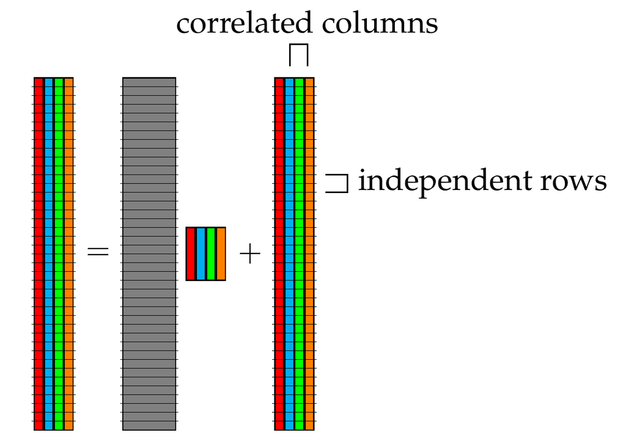

# Likelihood function

The likehood for one sample unit is
$$\begin{aligned}
L(\boldsymbol{B},\Sigma,\mathbf{Y}_{i.}) =
(2\pi)^{-r/2} |\Sigma|^{-1/2}
\exp\left\{
-\frac{1}{2}
(\mathbf{Y}_{i.} - \mathbf{X}_{i.}\boldsymbol{B})
\Sigma^{-1}
(\mathbf{Y}_{i.} - \mathbf{X}_{i.}\boldsymbol{B})'
\right\}
\end{aligned}$$

For all sample units is

$$\begin{aligned}
L(\boldsymbol{B},\Sigma,\mathbf{Y}) &= \prod_{i = 1}^n
(2\pi)^{-r/2} |\Sigma|^{-1/2}
\exp\left\{
-\frac{1}{2}
(\mathbf{Y}_{i.} - \mathbf{X}_{i.}\boldsymbol{B})
\Sigma^{-1}
(\mathbf{Y}_{i.} - \mathbf{X}_{i.}\boldsymbol{B})'
\right\}\\
&= (2\pi)^{-nr/2} |\Sigma|^{-n/2}
\exp\left\{
-\frac{1}{2} \sum_{i = 1}^n
(\mathbf{Y}_{i.} - \mathbf{X}_{i.}\boldsymbol{B})
\Sigma^{-1}
(\mathbf{Y}_{i.} - \mathbf{X}_{i.}\boldsymbol{B})'
\right\}.
\end{aligned}$$

Using the vectorize ($\text{vec}$) operation and kronecker product ($\otimes$), the observed data can be reshaped from wide to long format.

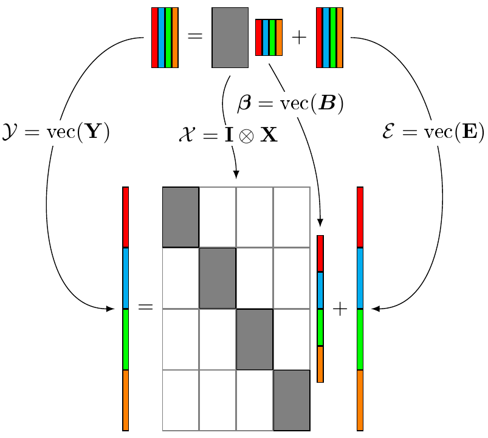

The same model is now represented by
$$\mathcal{Y} \sim
\text{Normal}_{rn}(\mathcal{X}\boldsymbol{\beta}, \Omega),$$
where $\Omega = \Sigma \otimes \mathbf{I}$.

Also, it can be written as
$$\mathcal{Y} = \mathcal{X}\boldsymbol{\beta} + \mathcal{E}.$$

In the stacked data format, the likelihood function is defined as
$$L(\boldsymbol{\beta}, \Omega) =
(2\pi)^{ -\frac{rn}{2} } |\Omega|^{-\frac{1}{2}}
\exp \left\{
-\frac{1}{2}
(\mathcal{Y} - \mathcal{X}\boldsymbol{\beta})^{'}
\Omega^{-1}
(\mathcal{Y} - \mathcal{X}\boldsymbol{\beta})
\right\}.$$

The maximized likelihood is
$$\begin{aligned}
L(\boldsymbol{\hat\beta}, \hat\Omega)
&= (2\pi)^{-rn/2} |\hat\Sigma \otimes \mathbf{I}|^{-1/2}
\exp \left\{
-\frac{rn}{2}
\right\}\\
&= (2\pi)^{-rn/2} |\hat\Sigma|^{-n/2}
\exp \left\{
-\frac{rn}{2}
\right\}.
\end{aligned}$$

# Estimation and properties

$$\begin{aligned}
{\boldsymbol{\hat B}} &=
(\mathbf{X}'\mathbf{X})^{-1}\mathbf{X}'\mathbf{Y}\\
{\boldsymbol{\hat B}}_{.j} &=
(\mathbf{X}'\mathbf{X})^{-1}\mathbf{X}'\mathbf{Y}_{.j}\\
{\boldsymbol{\hat \beta}} &=
(\mathcal{X}'\mathcal{X})^{-1}\mathcal{X}'\mathcal{Y}\\
\text{Cov}({\boldsymbol{\hat\beta}}) &=
{\hat\Sigma} \otimes
(\mathbf{X}'\mathbf{X})^{-1}
= \begin{bmatrix}
\hat{\sigma}_{11}(\mathbf{X}'\mathbf{X})^{-1} &
\cdots &
\hat{\sigma}_{1r}(\mathbf{X}'\mathbf{X})^{-1} \\
\vdots & \ddots & \vdots \\
\hat{\sigma}_{r1}(\mathbf{X}'\mathbf{X})^{-1} &
\cdots &
\hat{\sigma}_{rr}(\mathbf{X}'\mathbf{X})^{-1}
\end{bmatrix}
\end{aligned}$$

# Hypotheses tests on $\boldsymbol{B}$ or $\boldsymbol{\beta}$

A linear hypothesis can be defined in two equivalent ways.

$$H_0: \mathbf{A}\boldsymbol{B}\mathbf{M} = \mathbf{C}
\quad \textrm{vs} \quad
H_1: \mathbf{A}\boldsymbol{B}\mathbf{M} \neq \mathbf{C}$$

where

- $\mathbf{A}$ is a $h \times k$ ($h = \text{rank}(\mathbf{A}) < k$) matrix.
- $\boldsymbol{B}$ is the $k \times r$ parameter matrix.
- $\mathbf{M}$ is a $r \times v$ ($v \leq r$) matrix of linear hypothesis on the responses. The most common scenario is when $\boldsymbol{M} = \boldsymbol{I}_r$.
- $\mathbf{C}$ is a $h \times v$ matrix.

Example of $\mathbf{A}\boldsymbol{B}\mathbf{M} = \mathbf{C}$ to test $H_0: \eta_{mj} = 0$ for all $mj$, $m = 1, 2; j = 2, \ldots, 4$. These matrices are

$$\begin{aligned}
\begin{bmatrix}
0 & 0 & 0 & \textcolor{red}{1} & 0 & 0 \\
0 & 0 & 0 & 0 & \textcolor{red}{1} & 0 \\
0 & 0 & 0 & 0 & 0 & \textcolor{red}{1} \\
\end{bmatrix}
\begin{bmatrix}
\mu_{10} & \mu_{20} \\
\gamma_{12} & \gamma_{22} \\
\gamma_{13} & \gamma_{23} \\
\textcolor{red}{\eta_{12}} & \textcolor{red}{\eta_{22}} \\
\textcolor{red}{\eta_{13}} & \textcolor{red}{\eta_{23}} \\
\textcolor{red}{\eta_{14}} & \textcolor{red}{\eta_{24}} \\
\end{bmatrix}
\begin{bmatrix}
1 & 0 \\
0 & 1 \\
\end{bmatrix}
&= \begin{bmatrix}
0 & 0 \\
0 & 0 \\
0 & 0 \\
\end{bmatrix}
\\\Rightarrow\begin{bmatrix}
\textcolor{red}{\eta_{12}} & \textcolor{red}{\eta_{22}} \\
\textcolor{red}{\eta_{13}} & \textcolor{red}{\eta_{23}} \\
\textcolor{red}{\eta_{14}} & \textcolor{red}{\eta_{24}} \\
\end{bmatrix}
&= \begin{bmatrix}
0 & 0 \\
0 & 0 \\
0 & 0 \\
\end{bmatrix}
.\end{aligned}$$

The same linear hypothesis can be represented in using the vectorized form of $\boldsymbol{B}$, $\boldsymbol{\beta}$

$$H_0: \mathbf{L}\boldsymbol{\beta} = \mathbf{c}
\quad \textrm{vs} \quad
H_1: \mathbf{L}\boldsymbol{\beta} \neq \mathbf{c}$$

where

$$\begin{bmatrix}
0 & 0 & 0 & \textcolor{red}{1} & 0 & 0 & 0 & 0 & 0 & 0 & 0 & 0 \\
0 & 0 & 0 & 0 & \textcolor{red}{1} & 0 & 0 & 0 & 0 & 0 & 0 & 0 \\
0 & 0 & 0 & 0 & 0 & \textcolor{red}{1} & 0 & 0 & 0 & 0 & 0 & 0 \\
0 & 0 & 0 & 0 & 0 & 0 & 0 & 0 & 0 & \textcolor{red}{1} & 0 & 0 \\
0 & 0 & 0 & 0 & 0 & 0 & 0 & 0 & 0 & 0 & \textcolor{red}{1} & 0 \\
0 & 0 & 0 & 0 & 0 & 0 & 0 & 0 & 0 & 0 & 0 & \textcolor{red}{1} \\
\end{bmatrix}
\begin{bmatrix}
\mu_{10} \\
\gamma_{12} \\
\gamma_{13} \\
\textcolor{red}{\eta_{12}} \\
\textcolor{red}{\eta_{13}} \\
\textcolor{red}{\eta_{14}} \\
\mu_{20} \\
\gamma_{22} \\
\gamma_{23} \\
\textcolor{red}{\eta_{22}} \\
\textcolor{red}{\eta_{23}} \\
\textcolor{red}{\eta_{24}} \\
\end{bmatrix}
= \begin{bmatrix}
0 \\
0 \\
0 \\
0 \\
0 \\
0 \\
\end{bmatrix}
.$$

Let $\mathbf{R}$ be the residual sum of squares and cross products (SSP) of the full model
$$\mathbf{R} = (\mathbf{Y} - \mathbf{X}\boldsymbol{\hat{B}})'
(\mathbf{Y} - \mathbf{X}\boldsymbol{\hat{B}}).$$

Defines $\mathbf{H}$ as the hypothesis SSP matrix,
$$\begin{aligned}
\mathbf{H}
&= n(\hat{\Sigma}_0 - \hat{\Sigma})\\
&= (\mathbf{A}\boldsymbol{\hat{B}}\mathbf{M} - \mathbf{C})'
[\mathbf{A} (\mathbf{X}'\mathbf{X})^{-1} \mathbf{A}']^{-1}
(\mathbf{A}\boldsymbol{\hat{B}}\mathbf{M} - \mathbf{C}),
\end{aligned}$$

The statistic
$$\text{tr} (\mathbf{H}\mathbf{R}^{-1}) = \sum_{i = 1}^{s} \lambda_i$$
is known as *Hotteling-Lawley trace*. The values $\lambda_1 \geq \lambda_2 \geq \ldots \lambda_s$ are the nonzero eigen values of $\mathbf{H}\mathbf{R}^{-1}$.

Berndt e Savin (1977) show that the same value is obtained as the result of a Wald test using the vectorized version of the components

$$\text{tr} (\mathbf{H}\mathbf{R}^{-1}) =
(\mathbf{L} \boldsymbol{\hat\beta} - \mathbf{c})'
[\mathbf{L} (
(\mathbf{M}' \mathbf{R} \mathbf{M}) \otimes
(\mathbf{X}'\mathbf{X})^{-1})
\mathbf{L}']^{-1}
(\mathbf{L} \boldsymbol{\hat\beta} - \mathbf{c}).$$

Under $H_0$, the statistic
$$n \text{tr} (\mathbf{H}\mathbf{R}^{-1}),$$
has a limiting $\chi^2$ distribution with $vh$ degrees of freedom.

A test based on the likelihood ratio is written in terms of generalized variances
$$\begin{aligned}
\Lambda
&= \frac{\max_{H_0} L(\beta, \Sigma)}{\max L(\beta, \Sigma)} \\
&= \left(\frac{|\hat{\Sigma}_0|}{|\hat{\Sigma}|}\right)^{-n/2},\\
\end{aligned}$$
and the *Wilks’ statistic* is
$$\Lambda^{2/n} = \frac{|\hat{\Sigma}|}{|\hat{\Sigma}_0|}.$$

Under $H_0$, $n\hat{\Sigma} \sim W_{r;n-k}$ independently of $n(\hat{\Sigma}_0 - \hat{\Sigma}) \sim W_{r;h}$. The likelihood ratio test of $H_0$ is equivalent to reject $H_0$ for large values of the deviance
$$-2 \log \Lambda =
-n \log
\left(
\frac{|n\hat{\Sigma}|}{
|n\hat{\Sigma} + n(\hat{\Sigma}_0 - \hat{\Sigma})|}
\right).$$

Under $H_0$, the above statistic has a limiting $\chi^2$ distribution with $vh$ degrees of freedom.

# The four multivariate hypothesis tests

For the same hypothesis, there are four multivariate tests.

$$\begin{aligned}
\text{Wilk's lambda}
&= \frac{|\mathbf{R}|}{|\mathbf{R} + \mathbf{H}|}
= \prod_{i=1}^s \frac{1}{1+\lambda_i}\\
\text{Hotelling-Lawley trace}
&= \text{tr}(\mathbf{H}\mathbf{R}^{-1})
= \sum_{i=1}^s \lambda_i\\
\text{Pillai's trace}
&= \text{tr}(\mathbf{H}(\mathbf{H} + \mathbf{R})^{-1})
= \sum_{i=1}^s \frac{\lambda_i}{1+\lambda_i}\\
\text{Roy's greatest root}
&= \max(\lambda_1,\ldots,\lambda_s) = \lambda_1
\end{aligned}$$

[figure not shown]

# Recomendations

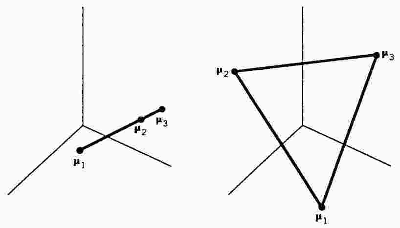

- They differ in the way they measure the evidence against the null hypothesis.
- The multivariate space offers many perspectives.
- Some general recomendations are:
  - Roy’s largest root is the most powerful if one linear function of the variables can resume the results well.
  - Pillai’s trace is the most used because it is more robust to departures from the assumptions.
  - Wilks is appealing because it is a LRT.
  - Hotteling-Lawley is a generalization of the $T^2$ statistic and can be directlty applied for non Gaussian contexts.

# Canonical discriminant analysis.

- Related to canonical correlation and principal components.
- Based on eigen values decomposition.
- A very interesting complement for multivariate analysis.
- Finds linear combinations of the responses variables that maximizes the effect of preditors.

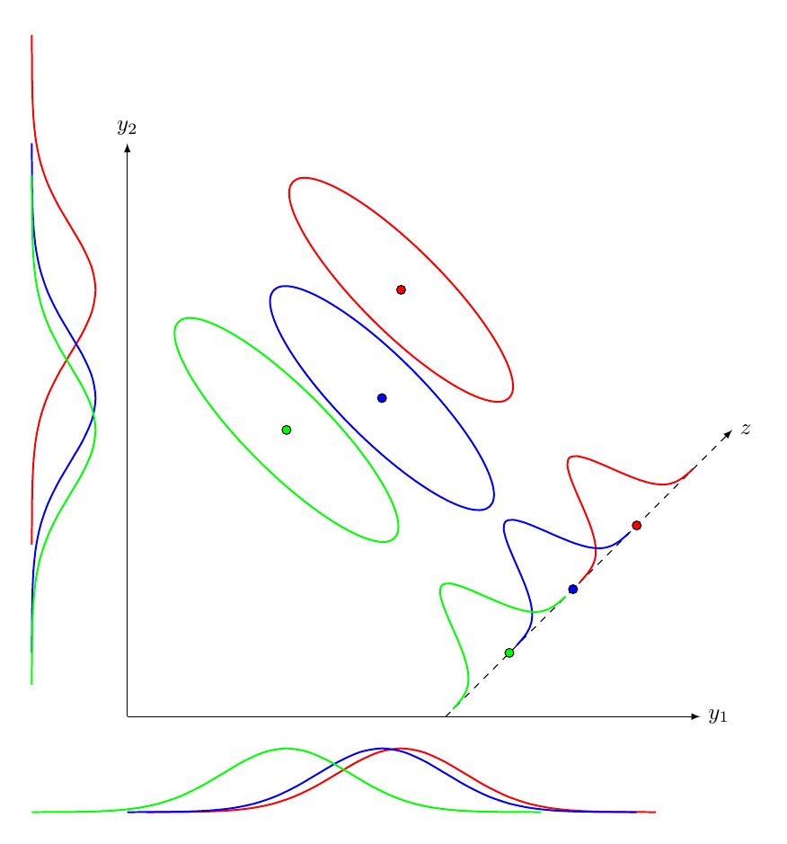

# Examples

# Additional topics

- Assumptions: all depends on the Holy Trinity of Normality, Homoscedasticity and Independence.
- Diagnostics: there are some visual and hypothesis based approaches to diagnostic departures from the Holy Trinity.
- Beyond the scope of this course.
- Limitations:
  - Missigns in some responses for a sample unit implies in deletion of the entire sample unit.
- Extensions:
  - Multiple design MLM (responses with different sets of predictors).
  - Predictors with random effects (random/mixed MLM).
  - Correlations between sample units (split-plot design).
  - Non-gaussian responses.
  - and more.

# References

Berndt, Ernst R., e N. Eugene Savin. 1977. “Conflict among criteria for testing hypotheses in the multivariate linear regression model”. *Econometrica* 45 (5). JSTOR: 1263. doi:10.2307/1914072.